# Introduction to Python Project : FoodHub Data Analysis

### Problem Statement

The number of restaurants in New York is growing, and many students and professionals rely on online food delivery services due to their busy lifestyles. FoodHub, a food aggregator, connects customers with multiple restaurants through a mobile app, handling order placement, restaurant confirmation, and delivery.

FoodHub has collected data on customer orders and wants to analyze it to understand restaurant demand and improve customer experience. As a Data Scientist, my task is to analyze the provided dataset, answer key business questions, and derive insights to enhance FoodHub’s operations and profitability.

### Data Dictionary

order_id – Unique ID of the order.

customer_id – ID of the customer who placed the order.

restaurant_name – Name of the restaurant from which the order was placed.

cuisine_type – Type of cuisine ordered by the customer.

cost_of_the_order – Price paid for the order.

day_of_the_week – Indicates whether the order was placed on a weekday (Monday to Friday) or weekend (Saturday and Sunday).

rating – Customer rating for the order (out of 5).

food_preparation_time – Time (in minutes) taken by the restaurant to prepare the food.

delivery_time – Time (in minutes) taken by the delivery person to deliver the food to the customer.

### Let us start by importing the required libraries

```python
# conda create --name gl python=3.11
# conda activate gl

# Install the required libraries
!pip install -U pandas numpy matplotlib seaborn scikit-learn

# Import the required libraries
import pandas as pd
import numpy as np
import matplotlib.pyplot as plt
import seaborn as sns
```

### Understanding the structure of the data

```python
# uncomment and run the following lines for Google Colab
# from google.colab import drive
# drive.mount('/content/drive')

# I am using the data from the local machine
# df = pd.read_csv('./data/foodhub_order.csv')
```

```python
# Write your code here to read the data
df = pd.read_csv('./data/foodhub_order.csv')
```

```python
# Write your code here to view the first 5 rows
df.head()
```

|  | order_id | customer_id | restaurant_name | cuisine_type | cost_of_the_order | day_of_the_week | rating | food_preparation_time | delivery_time |
| --- | --- | --- | --- | --- | --- | --- | --- | --- | --- |
| 0 | 1477147 | 337525 | Hangawi | Korean | 30.75 | Weekend | Not given | 25 | 20 |
| 1 | 1477685 | 358141 | Blue Ribbon Sushi Izakaya | Japanese | 12.08 | Weekend | Not given | 25 | 23 |
| 2 | 1477070 | 66393 | Cafe Habana | Mexican | 12.23 | Weekday | 5 | 23 | 28 |
| 3 | 1477334 | 106968 | Blue Ribbon Fried Chicken | American | 29.20 | Weekend | 3 | 25 | 15 |
| 4 | 1478249 | 76942 | Dirty Bird to Go | American | 11.59 | Weekday | 4 | 25 | 24 |

### **Question 1:** How many rows and columns are present in the data? [0.5 mark]

```python
# Write your code here
print("Shape:", df.shape)
print("--------------------------------")


print(f"Total number of rows: {df.shape[0]} and total number of columns: {df.shape[1]}")
```

```
Shape: (1898, 9)
--------------------------------
Total number of rows: 1898 and total number of columns: 9
```

#### Observations:

### **Question 2:** What are the datatypes of the different columns in the dataset? (The info() function can be used) [0.5 mark]

```python
# Write your code here
print("Data Info:", df.info())
```

```
<class 'pandas.core.frame.DataFrame'>
RangeIndex: 1898 entries, 0 to 1897
Data columns (total 9 columns):
 #   Column                 Non-Null Count  Dtype
---  ------                 --------------  -----
 0   order_id               1898 non-null   int64
 1   customer_id            1898 non-null   int64
 2   restaurant_name        1898 non-null   object
 3   cuisine_type           1898 non-null   object
 4   cost_of_the_order      1898 non-null   float64
 5   day_of_the_week        1898 non-null   object
 6   rating                 1898 non-null   object
 7   food_preparation_time  1898 non-null   int64
 8   delivery_time          1898 non-null   int64
dtypes: float64(1), int64(4), object(4)
memory usage: 133.6+ KB
Data Info: None
```

#### Observations:

### **Question 3:** Are there any missing values in the data? If yes, treat them using an appropriate method. [1 mark]

```python
# Write your code here
print(df.isnull().sum())
print("--------------------------------")


print(f"There are {df.isnull().sum().sum()} missing values in the data")
```

```
order_id                 0
customer_id              0
restaurant_name          0
cuisine_type             0
cost_of_the_order        0
day_of_the_week          0
rating                   0
food_preparation_time    0
delivery_time            0
dtype: int64
--------------------------------
There are 0 missing values in the data
```

#### Observations:

### **Question 4:** Check the statistical summary of the data. What is the minimum, average, and maximum time it takes for food to be prepared once an order is placed? [2 marks]

```python
# Write your code here
print(df.describe())
print("--------------------------------")


print("Minimum time to prepare the food:", df["food_preparation_time"].min())
print("Average time to prepare the food:", df["food_preparation_time"].mean())
print("Maximum time to prepare the food:", df["food_preparation_time"].max())
```

```
           order_id    customer_id  cost_of_the_order  food_preparation_time  \
count  1.898000e+03    1898.000000        1898.000000            1898.000000
mean   1.477496e+06  171168.478398          16.498851              27.371970
std    5.480497e+02  113698.139743           7.483812               4.632481
min    1.476547e+06    1311.000000           4.470000              20.000000
25%    1.477021e+06   77787.750000          12.080000              23.000000
50%    1.477496e+06  128600.000000          14.140000              27.000000
75%    1.477970e+06  270525.000000          22.297500              31.000000
max    1.478444e+06  405334.000000          35.410000              35.000000

       delivery_time
count    1898.000000
mean       24.161749
std         4.972637
min        15.000000
25%        20.000000
50%        25.000000
75%        28.000000
max        33.000000
--------------------------------
Minimum time to prepare the food: 20
Average time to prepare the food: 27.371970495258168
Maximum time to prepare the food: 35
```

#### Observations:

### **Question 5:** How many orders are not rated? [1 mark]

```python
# Write the code here
print(f"There are {df[df['rating'] == 'Not given'].shape[0]} orders that are not rated")
```

```
There are 736 orders that are not rated
```

#### Observations:

### Exploratory Data Analysis (EDA)

### **Question 6:** Explore all the variables and provide observations on their distributions. (Generally, histograms, boxplots, countplots, etc. are used for univariate exploration.) [9 marks]

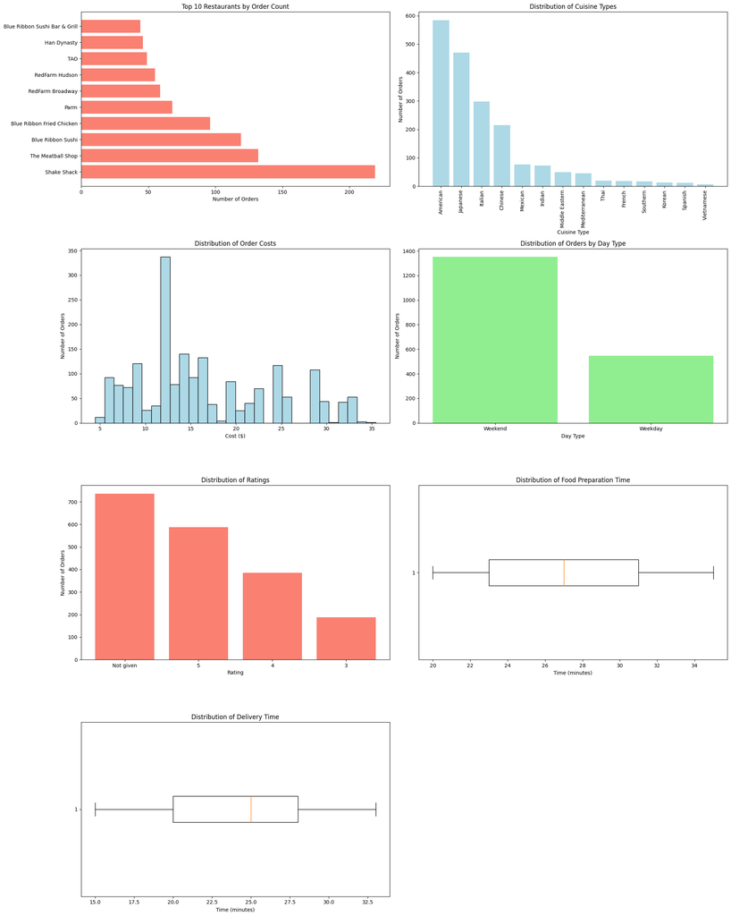

```
Summary Statistics:
           order_id    customer_id  cost_of_the_order  food_preparation_time  \
count  1.898000e+03    1898.000000        1898.000000            1898.000000
mean   1.477496e+06  171168.478398          16.498851              27.371970
std    5.480497e+02  113698.139743           7.483812               4.632481
min    1.476547e+06    1311.000000           4.470000              20.000000
25%    1.477021e+06   77787.750000          12.080000              23.000000
50%    1.477496e+06  128600.000000          14.140000              27.000000
75%    1.477970e+06  270525.000000          22.297500              31.000000
max    1.478444e+06  405334.000000          35.410000              35.000000

       delivery_time
count    1898.000000
mean       24.161749
std         4.972637
min        15.000000
25%        20.000000
50%        25.000000
75%        28.000000
max        33.000000
```

```python
# Write the code here

# Set up the plotting style
fig = plt.figure(figsize=(20,25))

# 1. Restaurant distribution
plt.subplot(421)
restaurant_counts = df['restaurant_name'].value_counts()[:10]
plt.barh(restaurant_counts.index, restaurant_counts.values, color='salmon')
plt.title('Top 10 Restaurants by Order Count')
plt.xlabel('Number of Orders')

# 2. Cuisine type distribution
plt.subplot(422)
cuisine_counts = df['cuisine_type'].value_counts()
plt.bar(cuisine_counts.index, cuisine_counts.values, color='lightblue')
plt.title('Distribution of Cuisine Types')
plt.xlabel('Cuisine Type')
plt.ylabel('Number of Orders')
plt.xticks(rotation=90)  # Tilt x-axis labels by 9 degrees

# 3. Cost distribution
plt.subplot(423)
plt.hist(df['cost_of_the_order'], bins=30, color='lightblue', edgecolor='black')
plt.title('Distribution of Order Costs')
plt.xlabel('Cost ($)')
plt.ylabel('Number of Orders')

# 4. Day of the week distribution
plt.subplot(424)
weekday_counts = df['day_of_the_week'].value_counts()
plt.bar(weekday_counts.index, weekday_counts.values, color='lightgreen')
plt.title('Distribution of Orders by Day Type')
plt.xlabel('Day Type')
plt.ylabel('Number of Orders')

# 5. Rating distribution
plt.subplot(425)
rating_counts = df['rating'].value_counts()
plt.bar(rating_counts.index, rating_counts.values, color='salmon')
plt.title('Distribution of Ratings')
plt.xlabel('Rating')
plt.ylabel('Number of Orders')

# 6. Food Preparation Time distribution
plt.subplot(426)
plt.boxplot(df['food_preparation_time'], vert=False)
plt.title('Distribution of Food Preparation Time')
plt.xlabel('Time (minutes)')

# 7. Delivery Time distribution
plt.subplot(427)
plt.boxplot(df['delivery_time'], vert=False)
plt.title('Distribution of Delivery Time')
plt.xlabel('Time (minutes)')

plt.tight_layout()
plt.show()

# Print summary statistics
print("\nSummary Statistics:")
print(df.describe())
```

## Some pointers from the analysis

> Order distribution is right-skewed (positively skewed) and long-tail distribution, where a small number of restaurants dominate the order volume, while the majority receive relatively fewer orders.

> Cuisine distribution is right-skewed, with American and Japanese cuisines receiving significantly higher orders, while others like Thai and French have much lower counts.

> Weekday vs Weekend distribution is right-skewed, with significantly more orders on weekends than on weekdays

### **Question 7**: Which are the top 5 restaurants in terms of the number of orders received? [1 mark]

```python
# Write the code here
restaurant_counts = df['restaurant_name'].value_counts()[:10]
print("Top 5 restaurants in terms of the number of orders received:")
print(restaurant_counts)
```

```
Top 5 restaurants in terms of the number of orders received:
restaurant_name
Shake Shack                      219
The Meatball Shop                132
Blue Ribbon Sushi                119
Blue Ribbon Fried Chicken         96
Parm                              68
RedFarm Broadway                  59
RedFarm Hudson                    55
TAO                               49
Han Dynasty                       46
Blue Ribbon Sushi Bar & Grill     44
Name: count, dtype: int64
```

#### Observations:

### **Question 8**: Which is the most popular cuisine on weekends? [1 mark]

```python
# Write the code here
cuisine_counts = df[df['day_of_the_week'] == 'Weekend']['cuisine_type'].value_counts()[:5]
print("Most popular 5 cuisines on weekends:")
print(cuisine_counts)
```

```
Most popular 5 cuisines on weekends:
cuisine_type
American    415
Japanese    335
Italian     207
Chinese     163
Mexican      53
Name: count, dtype: int64
```

#### Observations:

### **Question 9**: What percentage of the orders cost more than 20 dollars? [2 marks]

```python
# Write the code here
orders_above_20 = (df['cost_of_the_order'] > 20).sum()
percentage_orders_above_20 = (orders_above_20 / len(df)) * 100
print(f"Percentage of orders costing more than $20: {percentage_orders_above_20:.2%}")
```

```
Percentage of orders costing more than $20: 2924.13%
```

#### Observations:

### **Question 10**: What is the mean order delivery time? [1 mark]

```python
# Write the code here
mean_delivery_time = df['delivery_time'].mean()
print(f"Mean order delivery time: {mean_delivery_time:.2f} minutes")
```

```
Mean order delivery time: 24.16 minutes
```

#### Observations:

### **Question 11:** The company has decided to give 20% discount vouchers to the top 3 most frequent customers. Find the IDs of these customers and the number of orders they placed. [1 mark]

```python
# Write the code here
customer_orders = df.groupby('customer_id')['order_id'].count().sort_values(ascending=False)
top_3_customers = customer_orders.head(3)
print("Top 3 customers by number of orders:")
print(top_3_customers)
```

```
Top 3 customers by number of orders:
customer_id
52832    13
47440    10
83287     9
Name: order_id, dtype: int64
```

#### Observations:

### **Question 12**: Perform a multivariate analysis to explore relationships between the important variables in the dataset. (It is a good idea to explore relations between numerical variables as well as relations between numerical and categorical variables) [10 marks]

```python
df.head()
```

|  | order_id | customer_id | restaurant_name | cuisine_type | cost_of_the_order | day_of_the_week | rating | food_preparation_time | delivery_time |
| --- | --- | --- | --- | --- | --- | --- | --- | --- | --- |
| 0 | 1477147 | 337525 | Hangawi | Korean | 30.75 | Weekend | Not given | 25 | 20 |
| 1 | 1477685 | 358141 | Blue Ribbon Sushi Izakaya | Japanese | 12.08 | Weekend | Not given | 25 | 23 |
| 2 | 1477070 | 66393 | Cafe Habana | Mexican | 12.23 | Weekday | 5 | 23 | 28 |
| 3 | 1477334 | 106968 | Blue Ribbon Fried Chicken | American | 29.20 | Weekend | 3 | 25 | 15 |
| 4 | 1478249 | 76942 | Dirty Bird to Go | American | 11.59 | Weekday | 4 | 25 | 24 |

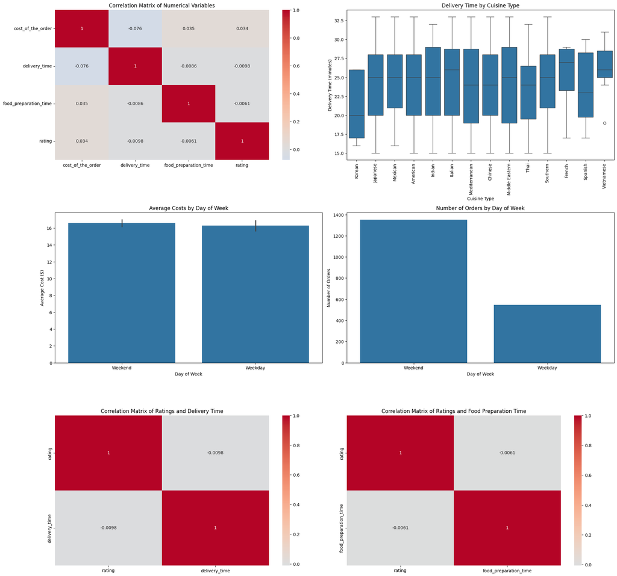

```python
# Write the code here

# Set up the plotting style
fig = plt.figure(figsize=(20,25))

# 1. Analyze relationship between cost and delivery metrics
df_for_correlation = df[['cost_of_the_order', 'delivery_time', 'food_preparation_time', 'rating']]
df_for_correlation = df_for_correlation[df_for_correlation['rating'] != 'Not given']
df_for_correlation['rating'] = df_for_correlation['rating'].astype(float)

plt.subplot(421)
sns.heatmap(df_for_correlation.corr(), annot=True, cmap='coolwarm', center=0)
plt.title('Correlation Matrix of Numerical Variables')

# 2. Analyze delivery times by cuisine type
plt.subplot(422)
sns.boxplot(x='cuisine_type', y='delivery_time', data=df)
plt.title('Delivery Time by Cuisine Type')
plt.xlabel('Cuisine Type')
plt.ylabel('Delivery Time (minutes)')
plt.xticks(rotation=90)

# 3. Analyze costs by day of week
plt.subplot(423)
sns.barplot(x='day_of_the_week', y='cost_of_the_order', data=df)
plt.title('Average Costs by Day of Week')
plt.xlabel('Day of Week')
plt.ylabel('Average Cost ($)')

# 4. Number of orders by weekday and weekend
plt.subplot(424)
sns.countplot(x='day_of_the_week', data=df)
plt.title('Number of Orders by Day of Week')
plt.xlabel('Day of Week')
plt.ylabel('Number of Orders')

# 5. Correlation matrix for ratings and delivery time
df_for_correlation = df[['rating', 'delivery_time']]
df_for_correlation = df_for_correlation[df_for_correlation['rating'] != 'Not given']
df_for_correlation['rating'] = df_for_correlation['rating'].astype(float)
plt.subplot(425)
sns.heatmap(df_for_correlation.corr(), annot=True, cmap='coolwarm', center=0)
plt.title('Correlation Matrix of Ratings and Delivery Time')

# 6. Correlation matrix for ratings and food preparation time
df_for_correlation = df[['rating', 'food_preparation_time']]
df_for_correlation = df_for_correlation[df_for_correlation['rating'] != 'Not given']
df_for_correlation['rating'] = df_for_correlation['rating'].astype(float)
plt.subplot(426)
sns.heatmap(df_for_correlation.corr(), annot=True, cmap='coolwarm', center=0)
plt.title('Correlation Matrix of Ratings and Food Preparation Time')


plt.tight_layout()
plt.show()
```

## Some pointers from the analysis

> Cost vs. Delivery Time: A slight negative correlation (-0.0759) suggests that higher-cost orders may have slightly faster delivery, but the effect is very weak. Cost vs. Rating: A very weak positive correlation (0.0340) indicates that higher-cost orders might receive slightly better ratings, but the impact is minimal.

> Food Preparation Time vs. Rating: Almost no correlation (-0.0061), meaning longer prep times do not significantly affect ratings.

> Delivery Time vs. Rating: No real relationship (-0.0098), suggesting customers do not strongly rate based on delivery speed.

> Cuisines and Delivery Time: Different cuisines have different delivery times, but no clear pattern is seen.

> Customers do not strongly rate orders based on delivery time, suggesting other factors (like food quality) may matter more.

### **Question 13:** The company wants to provide a promotional offer in the advertisement of the restaurants. The condition to get the offer is that the restaurants must have a rating count of more than 50 and the average rating should be greater than 4. Find the restaurants fulfilling the criteria to get the promotional offer. [3 marks]

```python
# Write the code here
df_with_ratings = df[df['rating'] != 'Not given']
df_with_ratings['rating'] = df_with_ratings['rating'].astype(float)
filtered_ratings = df_with_ratings.groupby('restaurant_name').agg({
    'rating': ['count', 'mean']
}).reset_index()
filtered_ratings.columns = ['restaurant_name', 'rating_count', 'avg_rating']

promotional_restaurants = filtered_ratings[
    (filtered_ratings['rating_count'] > 50) &
    (filtered_ratings['avg_rating'] > 4)
]

print("Restaurants eligible for promotional offer:")
print("\nRestaurants meeting criteria (>50 ratings, >4 avg rating):")
print(promotional_restaurants.to_string(index=False))

print(f"\nTotal number of eligible restaurants: {len(promotional_restaurants)}")
```

```
Restaurants eligible for promotional offer:

Restaurants meeting criteria (>50 ratings, >4 avg rating):
          restaurant_name  rating_count  avg_rating
Blue Ribbon Fried Chicken            64    4.328125
        Blue Ribbon Sushi            73    4.219178
              Shake Shack           133    4.278195
        The Meatball Shop            84    4.511905

Total number of eligible restaurants: 4
```

#### Observations:

### **Question 14:** The company charges the restaurant 25% on the orders having cost greater than 20 dollars and 15% on the orders having cost greater than 5 dollars. Find the net revenue generated by the company across all orders. [3 marks]

```python
# Write the code here
df['company_revenue'] = np.where(df['cost_of_the_order'] > 20, df['cost_of_the_order'] * 0.25, np.where(df['cost_of_the_order'] > 5, df['cost_of_the_order'] * 0.15, 0))

print(f"Net revenue generated by the company across all orders: ${df['company_revenue'].sum():.2f}")
```

```
Net revenue generated by the company across all orders: $6166.30
```

#### Observations:

### **Question 15:** The company wants to analyze the total time required to deliver the food. What percentage of orders take more than 60 minutes to get delivered from the time the order is placed? (The food has to be prepared and then delivered.) [2 marks]

```python
# Write the code here
df['total_time'] = df['delivery_time'] + df['food_preparation_time']
df['total_time'].describe()

more_than_60_minutes = df[df['total_time'] > 60]
print(f"Percentage of orders taking more than 60 minutes to get delivered: {len(more_than_60_minutes) / len(df) * 100:.2f}%")
```

```
Percentage of orders taking more than 60 minutes to get delivered: 10.54%
```

#### Observations:

### **Question 16:** The company wants to analyze the delivery time of the orders on weekdays and weekends. How does the mean delivery time vary during weekdays and weekends? [2 marks]

```python
# Write the code here
weekday_delivery = df[df['day_of_the_week'] == 'Weekday']['delivery_time'].mean()
weekend_delivery = df[df['day_of_the_week'] == 'Weekend']['delivery_time'].mean()

print(f"Mean delivery time on weekdays: {weekday_delivery:.2f} minutes")
print(f"Mean delivery time on weekends: {weekend_delivery:.2f} minutes")
print(f"\nDifference in delivery time (Weekend - Weekday): {weekend_delivery - weekday_delivery:.2f} minutes")
```

```
Mean delivery time on weekdays: 28.34 minutes
Mean delivery time on weekends: 22.47 minutes

Difference in delivery time (Weekend - Weekday): -5.87 minutes
```

#### Observations:

### Conclusion and Recommendations

### **Question 17:** What are your conclusions from the analysis? What recommendations would you like to share to help improve the business? (You can use cuisine type and feedback ratings to drive your business recommendations.) [6 marks]

### Conclusions:

- Cost vs. Delivery Time: A slight negative correlation (-0.0759) suggests that higher-cost orders may have slightly faster delivery, but the effect is very weak. Cost vs. Rating: A very weak positive correlation (0.0340) indicates that higher-cost orders might receive slightly better ratings, but the impact is minimal.
- Food Preparation Time vs. Rating: Almost no correlation (-0.0061), meaning longer prep times do not significantly affect ratings.
- Delivery Time vs. Rating: No real relationship (-0.0098), suggesting customers do not strongly rate based on delivery speed.
- Cuisines and Delivery Time: Different cuisines have different delivery times, but no clear pattern is seen.